# Week 4 Exercise

# Revisiting the GSE100687 dataset

For these exercises, we will re-visit the dataset from last weeks’ exercise; the published dataset with GEO accession number `GSE100687`. You will need to switch to the RStudio project that you created for this dataset.

**Exercise:** Create a new R markdown file and add the following code chunk to read the files from the GSE100687 dataset.

```r
library(readr)
library(dplyr)
library(tximport)
library(DESeq2)

sampleInfo <- read_tsv("meta_data/sampleInfo.txt")
tx2gene <- read_csv("tx2gene.csv",col_names = FALSE)

dirs <- list.files("salmon_output/")
quant_files <- list.files("salmon_output/",pattern="quant.sf",recursive = TRUE,full.names = TRUE)
names(quant_files) <- dirs
txi <- tximport(quant_files,
                type="salmon",
                tx2gene = tx2gene,
                ignoreTxVersion = TRUE)

dds <- DESeqDataSetFromTximport(txi, colData = sampleInfo,
                                design = ~Treated)

dds$CellLine <- as.factor(dds$CellLine)
```

```
class: DESeqDataSet
dim: 57914 6
metadata(1): version
assays(2): counts avgTxLength
rownames(57914): ENSG00000000003 ENSG00000000005 ... ENSG00000284747
  ENSG00000284748
rowData names(0):
colnames(6): SRR5788492 SRR5788493 ... SRR5788496 SRR5788497
colData names(4): SRR GSE CellLine Treated
```

We saw in the practical that the `plotCounts` function can provide a quick visualisation of counts across different sample groups

```r
plotCounts(dds, "ENSG00000000003", intgroup = "CellLine")
```

```
using 'avgTxLength' from assays(dds), correcting for library size
```

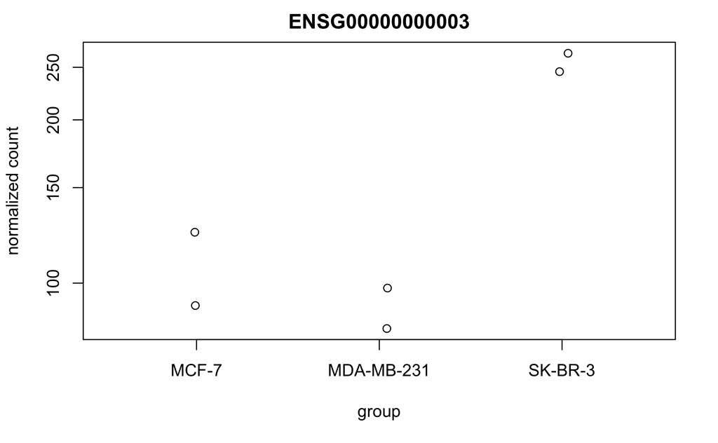

```
  Note: levels of factors in the design contain characters other than
  letters, numbers, '_' and '.'. It is recommended (but not required) to use
  only letters, numbers, and delimiters '_' or '.', as these are safe characters
  for column names in R. [This is a message, not a warning or an error]
using 'avgTxLength' from assays(dds), correcting for library size
```

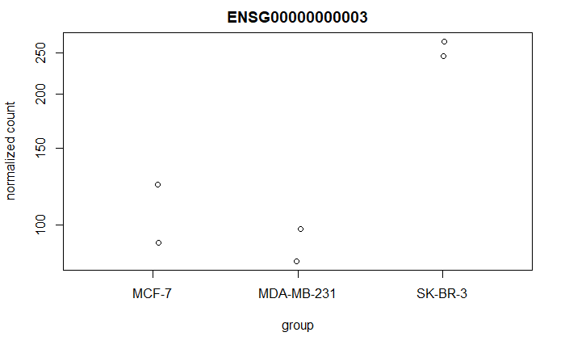

The plot doesn’t take full advantage of the `ggplot2` features that we have introduced recently. Fortunately, the authors have given the options for the data behind the plot to be retrieved.

```r
plotCounts(dds, "ENSG00000000003", intgroup = "CellLine",
           returnData = TRUE)
```

```
using 'avgTxLength' from assays(dds), correcting for library size
```

```
  Note: levels of factors in the design contain characters other than
  letters, numbers, '_' and '.'. It is recommended (but not required) to use
  only letters, numbers, and delimiters '_' or '.', as these are safe characters
  for column names in R. [This is a message, not a warning or an error]
using 'avgTxLength' from assays(dds), correcting for library size
```

|  | count | CellLine |
| --- | --- | --- |
| SRR5788492 | 124.10677 | MCF-7 |
| SRR5788493 | 90.91849 | MCF-7 |
| SRR5788494 | 245.44462 | SK-BR-3 |
| SRR5788495 | 265.34821 | SK-BR-3 |
| SRR5788496 | 82.45899 | MDA-MB-231 |
| SRR5788497 | 97.91901 | MDA-MB-231 |

In order to make use of the *meta data* we have recorded for these samples, we need to join the table to the `sampleInfo` data frame we created earlier. The sample identifiers (`SRR`) appear as rownames, and not columns in the data frame itself. The `rownames_to_column` function can be used to create such a column. You can now join the sampleInfo and counts into a single data frame for plotting.

```r
plotCounts(dds, "ENSG00000000003", intgroup = "CellLine",
           returnData = TRUE) %>%
  tibble::rownames_to_column("SRR")
```

```
using 'avgTxLength' from assays(dds), correcting for library size
```

```
  Note: levels of factors in the design contain characters other than
  letters, numbers, '_' and '.'. It is recommended (but not required) to use
  only letters, numbers, and delimiters '_' or '.', as these are safe characters
  for column names in R. [This is a message, not a warning or an error]
using 'avgTxLength' from assays(dds), correcting for library size
```

| SRR | count | CellLine |
| --- | --- | --- |
| SRR5788492 | 124.10677 | MCF-7 |
| SRR5788493 | 90.91849 | MCF-7 |
| SRR5788494 | 245.44462 | SK-BR-3 |
| SRR5788495 | 265.34821 | SK-BR-3 |
| SRR5788496 | 82.45899 | MDA-MB-231 |
| SRR5788497 | 97.91901 | MDA-MB-231 |

**Exercise**: Use one of the `_join` functions from `dplyr` to create a single data frame with the counts for this gene and the sample information. Visualise the counts using `ggplot2` and colour the counts according to whether the sample has been treated or not. See below for an example, but feel free to customise the plot.

The `left_join` function can be used to join the counts with the sample information. It is recommended to use `geom_jitter` rather than `geom_point` to distinguish the points more easily.

```
using 'avgTxLength' from assays(dds), correcting for library size
```

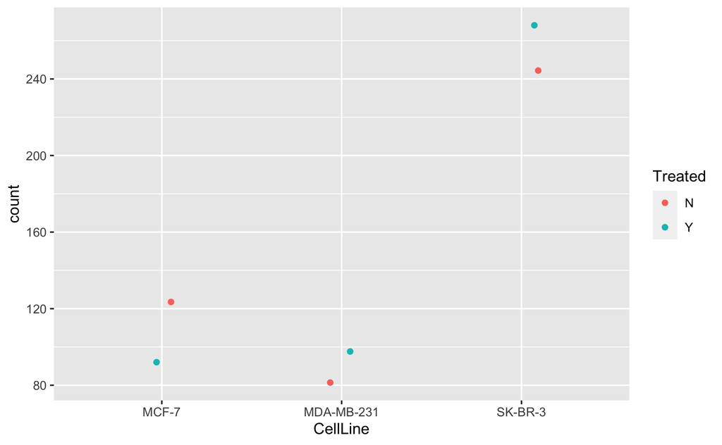

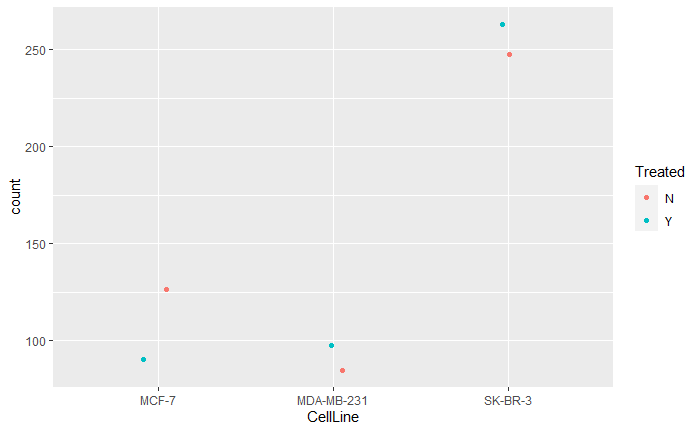

We saw in the practical that a PCA plot can help us decide what the main sources of variation in our dataset are - hopefully they should be the biological contrast that we are trying to compare. Before running a PCA, it is advisable to use a variance-stablising transformation.

```r
vsd <- vst(dds)
```

```
using 'avgTxLength' from assays(dds), correcting for library size
```

**Exercise**: Produce separate PCA plots using both `CellLine` and `Treated` as the `intgroup` argument. What do you notice? Do you think that the dataset will be effective at comparing Treated to Untreated samples?

**Exercise**: Proceed to use the `DESeq` function to identify genes that are differentially-expressed between treated and un-treated samples. Are you surprised by how many / how few genes have an adjusted p-value < 0.05?